# Graphical Analysis Assignment 01: Intro to Data Analytic Work

Welcome to Graphical Analysis of Data Analysis.

# 1 Teaching Team

## 1.1 Who am I?

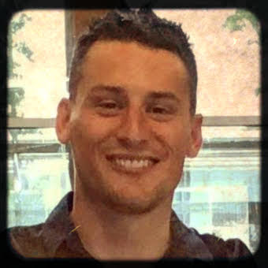

Dr. Vincenzo Coia  
Core teaching team of MDS  
Department of Statistics  
UBC

My Background:

- PhD in Statistics at UBC
- MSc in Mathematical Statistics at Brock U
- BSc in Math + Stats at Brock U
- BSc in Biology w/ Earth Science at Brock U

## 1.2 Meet your TA’s!

STAT 545 has four TA’s.

Sherrie

(photo missing)

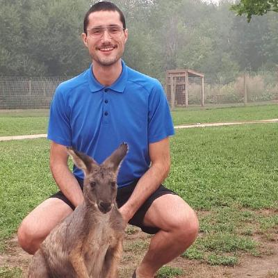

Chad

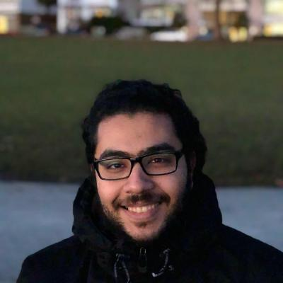

Hossam

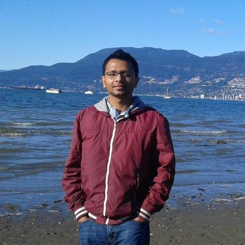

Rashedul

## 1.3 Meet your classmates

Get to know your neighbour! Choose someone to go first. In [2 minutes](https://www.youtube.com/watch?v=48z7nQaehWI), share:

- Your name
- Your program
- Something notable you did over the summer

Then switch for another two minutes.

Afterwards: let’s here from a few of you!

# 2 Today’s Outline

Here’s our agenda for today.

1. Go over the [course syllabus](http://stat545.com/Classroom).
2. Light exposure to some course tools: GitHub, the command line, markdown: [20 minute](https://www.youtube.com/watch?v=kxGWsHYITAw) periods. Lids down, please!
3. Do an activity.
   - Didn’t bring a device? Ask your neighbour if you can follow along!

By the end of today’s class, students are expected to be able to:

- Understand what is expected of them in the course
- List four ways to get help/converse about the course
- Navigate the STAT 545 GitHub framework, and their own profile
- Create and comment on GitHub Issues
- Explain how the course mantras apply in the case of this webpage
- Navigate the files of your computer using the command line

# 3 The syllabus

Let’s go over the [syllabus](http://stat545.com/Classroom) and the course assignments.

Other course destinations: defer until after we’re familiar with GitHub.

# 4 GitHub as a file-sharing and storage solution

Checklist:

- What are: Repositories (aka. “repo”s)
- Why: README’s
- What are: Issues
- What are: Organizations
- What are: Teams
- What is: GitHub pages

Next time: GitHub as a version-control system.

# 5 Course Destinations: revisited

Checklist:

- Org/repo/website diagram of STAT 545 destinations.
- Let’s spend time on:
  - Discussion repositories.
  - Students Org

# 6 Course Mantras

Here are some philosophies that will get you far in data analytic work. We will be revisiting these over and over again.

- Embrace plain text (as opposed to rich text) when authoring. (What is plain text?)
- Think in terms of source and output, and remember that source is real.
- Your stuff should be reproducible. Document, test, and leave a breadcrumb trail (version control), even when you are the only collaborator.

**Example**: markdown -> HTML. This webpage was generated from [this markdown source file](https://raw.githubusercontent.com/STAT545-UBC/Classroom/master/notes/cm001.Rmd) on GitHub.

# 7 The Shell

We will avoid this when we can, but we’ll at least need it to install *git* later. Here is the minimum need-to-know about the **shell**:

- Way to control your computer.
- OS-specific language!
  - Mac/linux/unix are about the same.
  - Windows has its own
- Navigate with `cd`, `pwd`, and `ls`. `.` and `..`.

A great introduction to this stuff is in [happygitwithr: Appendix A](http://happygitwithr.com/shell.html).

# 8 Activities

## 8.1 GitHub activity

[5 minute timer](https://www.youtube.com/watch?v=MxQWLbdGLfE).

1. Register for a GitHub.com account. Don’t pay!
   - Want detailed instructions? See [happygitwithr: Section 5](http://happygitwithr.com/github-acct.html)
2. Navigate to the Discussion-Internal repository.
3. Click `Watch` on the upper-right corner of the repo, so that you get email notifications.
4. Go to the Issues section of the repository, and comment on the Issue I created called “Introduce yourself!”. In the comment, say who you are, and greet the person above you – be sure to tag them by their username!
   - NOTE: The `Discussion-Internal` repo will be made private soon (you’ll have access).
5. Complete [this survey](https://goo.gl/forms/UPvRA6a9WRod8JPb2).
6. Please put up a profile photo – it makes the STAT 545 community more personable. You can do this from your profile homepage.
7. OPTIONAL: Register for the [Student Developer Pack](https://education.github.com/pack) with GitHub. It’s free!

## 8.2 Install your stuff

1. Install R and RStudio.
   - R here: https://cloud.r-project.org
   - RStudio here: https://www.rstudio.com/products/rstudio/download/preview/
   - Commentary on installing this stuff can be found at [stat545.com: r-rstudio-install](http://stat545.com/block000_r-rstudio-install.html)
2. Install git. See [happygitwithr: Section 7](http://happygitwithr.com/install-git.html)
   - You’ll need to work with the command line.

# 9 To do

If you haven’t already, please do the following before next class:

- Complete activities under “Activities” section.
- Please fill out [this survey](https://goo.gl/forms/UPvRA6a9WRod8JPb2), so that I can give you a repo under the students Org.